# Exercise Book

Artificial Neural Networks in R

# 1. Prototyping an ANN in R

*Learning Objective: Get an initial intuition for how hyperparameters affect an ANN model*

You will find a simple Artifical Neural Network implemented in base R (i.e. no libraries) here: R/01_ann_prototype.R (This script is also in the directory `/R` of your RStudio session). You are NOT expected to follow all the details of the code, but rather an get an impression of an ANN prototype.

*Your task is to, make the script run and find and tune the hyperparameters `n_hidden`, `epochs` and `epsilon` to get a working model*

The model is working, when the `y_pred` values are equal to the `y_true` values in the right pane of the final plot. Technically, the model is actually working, when we can set a prediction threshold, which separates all true negatives `0` from true positives `1`. The left pane is the training progress and shows the meas squared error for each epoch (1 epoch = 1 run through all data points)

**When you have the script running and a working model, click here to see suggested hyperparameters**

- `n_hidden = 4` (The number of hidden neurons)
- `epochs = 200` (The number of training cycles)
- `epsilon = 0.01` (The learning rate, i.e. size of steps towards a better model)

Ok, so this was not particularly straight forward, it doesn’t scale and writing complicated models this way would be challenging, to say the least. Let us see if there is a better way.

When you are looking at the code, it might be a good idea to keep this visualisation in mind:

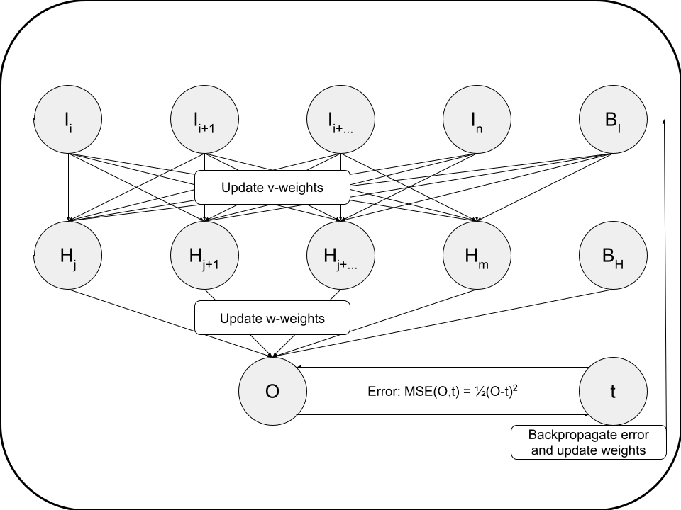

# 2. TensorFlow Playground

TensorFlow playground allows us to tinker with a neural network to get a better understanding of what is going on.

*Learning objective: Understand, that ANNs are universal approximators*

### Part I

1. Go to [TensorFlow Playground](https://playground.tensorflow.org)
2. Choose only features `X_1` and `X_2` (Find the FEATURES column)
3. Remove all hidden layers by clicking `-` next to ‘2 HIDDEN LAYERS’
4. Change activation from `Tanh` to `Sigmoid`, this means that we are now fitting `s(w_1x_1 + w_2_x_2 + b)`, where `s(t) = 1 / (1 + exp(-t))`, i.e. a logistic regression
5. Click the ‘play’ symbol in the upper left corner, which will start the training
6. Are we able to model the data?

**Click here, when you are done thinking**

No, if you look at the data on the right, it’s evident that a sigmoid function on untransformed input variables will not be able to create the needed discrimination

### Part II

1. Choose only features `X_1^2` and `X_2^2`. This means that we are now fitting `s(w_1x_1^2 + w_2_x_2^2 + b)` (Click blue/yellow squares under FEATURES to select or remove)
2. Check that we are still using `Sigmoid` activation
3. Click the ‘play’ symbol in the upper left corner, which will start the training
4. Are we able to model the data? What happened?

**Click here, when you are done thinking**

What happened here, was that we used our experience to look at the data and then transform the input variables. This is known as feature engineering.

### Part III

1. Choose only features `X_1` and `X_2`
2. Add 2 hidden layers with 4 neurons each by clicking `+` next to ‘HIDDEN LAYERS’ and `+` above each set of neurons
3. Click the ‘play’ symbol in the upper left corner, which will start the training
4. Are we able to model the data? What happened? (Note the number of epochs you reached, when the model was working)

**Click here, when you are done thinking**

What happened here, was that by adding complexicity to our model, we are now able to approximate the transformed variables we were working with in part II. The idea here being that in complex systems, often it is not clear if and how you need to transform your variables and the ANN will take care of that.

### Part IV

1. With the current setup, change the activation function to `ReLU`
2. What happened with the decision boundaries?
3. Change the number of neurons in the first layer to 3 and the number of neurons in the second layer to 2
4. What happened with the decision boundaries? (Note the number of epochs you reached, when the model was working and compare with the number in part III)

**Click here, when you are done thinking**

Sigmoid activation has the problem, that with small and large values, the gradient is close to zero, meaning that weights change very little. When using `ReLU` activation, this is no longer an issue and the model converges much more efficient with fewer epochs. From the decision bounadaries, you can see, that using the `ReLU` function corresponds to creating decision boundaries by joining linear segments and adding more neurons corresponds to adding more linear segments to perform the discrimination.

### Part V

1. Take 5 minutes to play around with TensorFlow Playground. Change the number of hidden layers and neurons in each. Re-run the same architecture several times. Do you obtain consistant discriminators?

# 3. Hello Keras

## Task

*Copy relevant code from below to R/02_hello_keras.R and create a working model*

Note how this is now a 3-class classifier and we are evaluating the predictive performance of the model on left out data.

### Introduction

The aim of this exercise is to let you build your first artificial neural network using Keras. Naturally, we will use the `iris` data set.

### Load libraries

```r
library("tidyverse")
library("keras")
```

### Data

[The famous Iris flower data set](https://en.wikipedia.org/wiki/Iris_flower_data_set) contains data to quantify the morphologic variation of Iris flowers of three related species. In other words - A total of 150 observations of 4 input features `Sepal.Length`, `Sepal.Width`, `Petal.Length` and `Petal.Width` and 3 output classes `setosa` `versicolor` and `virginica`, with 50 observations in each class:

```r
iris %>% head
```

```
##   Sepal.Length Sepal.Width Petal.Length Petal.Width Species
## 1          5.1         3.5          1.4         0.2  setosa
## 2          4.9         3.0          1.4         0.2  setosa
## 3          4.7         3.2          1.3         0.2  setosa
## 4          4.6         3.1          1.5         0.2  setosa
## 5          5.0         3.6          1.4         0.2  setosa
## 6          5.4         3.9          1.7         0.4  setosa
```

### Aim

Our aim is to create a model, which connect the 4 input features (`Sepal.Length`, `Sepal.Width`, `Petal.Length` and `Petal.Width`) to the correct output class (`setosa` `versicolor` and `virginica`) using an artificial neural network. For this task, we have chosen the following simple architecture:

- One input layer with 4 neurons (one for each feature)
- One hidden layer with 4 neurons
- One output layer with 3 neurons (one for each class):

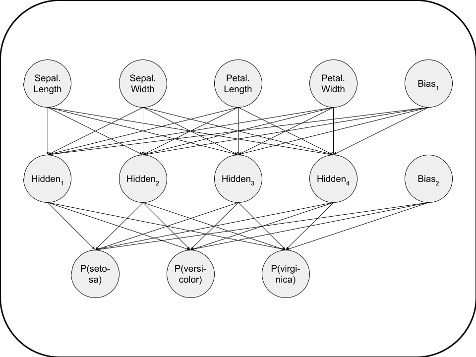

Our artificial neural network will have a total of 35 parameters:

- 4 for each of the 4 input neuron connected to the hidden layer
- an additional 4 for the associated first bias neuron
- 3 for each of the 4 hidden neurons connected to the output layer
- an additional 3 for the associated second bias neuron

I.e. 4 x 4 + 4 + 3 x 4 + 3 = 35

### 1. Prepare data

We start with slightly wrangling the iris data set by renaming the input features and converting character labels to numeric:

```r
nn_dat <- iris %>%
  as_tibble %>%
  rename(sepal_l_feat = Sepal.Length,
         sepal_w_feat = Sepal.Width,
         petal_l_feat = Petal.Length,
         petal_w_feat = Petal.Width) %>%
  mutate(class_num = as.numeric(Species) - 1, # factor, so = 0, 1, 2
         class_label = Species)
nn_dat %>%
  head(3)
```

```
## # A tibble: 3 × 7
##   sepal_l_feat sepal_w_feat petal_l_feat petal_w_feat Species class_num
##          <dbl>        <dbl>        <dbl>        <dbl> <fct>       <dbl>
## 1          5.1          3.5          1.4          0.2 setosa          0
## 2          4.9          3            1.4          0.2 setosa          0
## 3          4.7          3.2          1.3          0.2 setosa          0
## # … with 1 more variable: class_label <fct>
```

Then, we split the iris data into a training and a test data set, setting aside 20% of the data for left out data partition, to be used for final performance evaluation:

```r
test_f <- 0.20
nn_dat <- nn_dat %>%
  mutate(partition = sample(x = c("train","test"),
                            size = nrow(.),
                            replace = TRUE,
                            prob = c(1 - test_f, test_f)))
nn_dat %>%
  count(partition)
```

```
## # A tibble: 2 × 2
##   partition     n
##   <chr>     <int>
## 1 test         43
## 2 train       107
```

Based on the partition, we can now create training and test data

```r
# Training data
x_train <- nn_dat %>%
  filter(partition == "train") %>%
  select(contains("feat")) %>%
  as.matrix
y_train <- nn_dat %>%
  filter(partition == "train") %>%
  pull(class_num) %>%
  to_categorical(3)
```

```
## Loaded Tensorflow version 2.6.1
```

```r
# Test data
x_test <- nn_dat %>%
  filter(partition == "test") %>%
  select(contains("feat")) %>%
  as.matrix
y_test <- nn_dat %>%
  filter(partition == "test") %>%
  pull(class_num) %>%
  to_categorical(3)
```

### 2. Define model

```r
model <- keras_model_sequential() %>%
  layer_dense(units = 4, activation = "relu", input_shape = 4) %>%
  layer_dense(units = 3, activation = "softmax")
```

Compile model

```r
model %>%
  compile(loss = "categorical_crossentropy",
          optimizer = optimizer_adam(),
          metrics = c("accuracy")
)
```

We can get a summary of the model like so:

```r
model %>%
  summary
```

[output not shown]

As expected we see 35 trainable parameters.

### Train the Artificial Neural Network

Lastly we fit the model and save the training progres in the `history` object:

```r
history <- model %>%
  fit(x = x_train,
      y = y_train,
      epochs = 200,
      batch_size = 16,
      validation_split = 0
)
```

Once the model is trained, we can inspect the training process

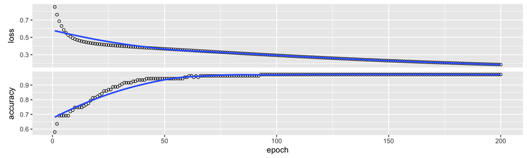

```r
plot(history)
```

### Evaluate Network Performance

The final performance can be obtained like so:

```r
perf <- model %>%
  evaluate(x_test, y_test)
perf
```

```
##      loss  accuracy
## 0.1939422 0.9767442
```

Then we can augment the `nn_dat` for plotting:

```r
plot_dat <- nn_dat %>%
  filter(partition == "test") %>%
  mutate(y_pred = predict(model, x_test) %>% apply(1, which.max) - 1,
         Correct = ifelse(class_num == y_pred, "Yes", "No"))
plot_dat %>%
  select(-contains("feat")) %>%
  head(3)
```

```
## # A tibble: 3 × 6
##   Species class_num class_label partition y_pred Correct
##   <fct>       <dbl> <fct>       <chr>      <dbl> <chr>
## 1 setosa          0 setosa      test           0 Yes
## 2 setosa          0 setosa      test           0 Yes
## 3 setosa          0 setosa      test           0 Yes
```

and lastly, we can visualise the confusion matrix like so:

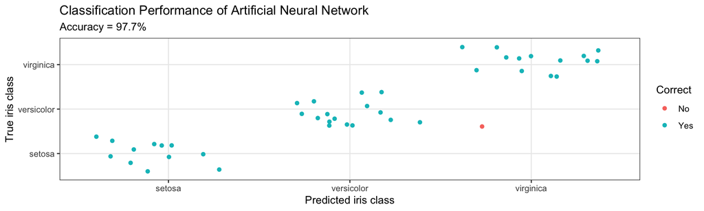

```r
plot_dat %>%
  ggplot(aes(x = factor(y_pred),
             y = factor(class_num),
             colour = Correct)) +
  geom_jitter() +
  scale_x_discrete(labels = levels(nn_dat$class_label)) +
  scale_y_discrete(labels = levels(nn_dat$class_label)) +
  theme_bw() +
  labs(title = "Classification Performance of Artificial Neural Network",
       subtitle = str_c("Accuracy = ", round(perf["accuracy"], 3) * 100, "%"),
       x = "Predicted iris class",
       y = "True iris class")
```

### Conclusion

Here, we created a 3-class predictor with an accuracy of 97.7% on a left out data partition. I hope, this illustrates how relatively simple it is to get started with `Keras`.

# 4a. Predicting commodity prices (regression)

You will find an Artifical Neural Network implemented in keras capable of predicting the price of a diamond here: R/04_diamonds_regression.R (This script is also in the directory `/R` of your RStudio session)

*Your task is to, make the script run and find and tune the hyperparameters to get a working model*

The model is working, when the `Actual Price of Diamond` is equal to the `Predicted Price of Diamond` in the final plot. (`y_pred` values are equal to the `y_true`, look for the dashed identity line).

**When you have the script running and a working model, click here to see suggested hyperparameters**

```r
n_epochs      <- 50
batch_size    <- 50
loss          <- "mean_squared_error"
learning_rate <- 0.001
optimzer      <- optimizer_adam(lr = learning_rate)
h1_activation <- "relu"
h1_n_hidden   <- 9
h2_activation <- "relu"
h2_n_hidden   <- 9
h3_activation <- "relu"
h3_n_hidden   <- 9
o_activation  <- "linear"
```

Try to use this as a reference and then increase or decrease the model complexity to see if you can find an even better architecture.

Be sure to think about the activation function for the last layer. If you are doing regression like here, then use linear. For binary classification, use sigmoid and for multiclass classification, use softmax.

# 4b. Deep Learning for Cancer Immunotherapy (Classification)

You will find an Artifical Neural Network implemented in keras capable of predicting if a given peptide will bind, i.e. the molecular interaction here: R/05_deep_learning_for_cancer_immunotherapy.R (This script is also in the directory `/R` of your RStudio session). This exercise is based on my invited post on the RStudio AI Blog: [Deep Learning for Cancer Immunotherapy](https://blogs.rstudio.com/ai/posts/2018-01-29-dl-for-cancer-immunotherapy/).

The model is working, when all class assignment are correct, i.e. when all of the data points appear in the diagonal in the final plot.

**When you are done thinking, click here for answers**

- **Q1**: `model %>% summary` will tell you. 280,623 at default architecture
- **Q2**: Because of the high model complexity, we are over-fitting
- **Q3**: It randomly masks updating of some weights aiming at avoiding overfitting. In the script drop out is set to 0, try changing it to 0.1 … 0.5
- **Q4**: `0, 7.005256e-05, 0.9999299` using the command `'LMAFYLYEV' %>% encode_peptide(m = bl62) %>% predict(model, .)`
- **Q5**: `1, 3.598115e-09, 0`, likewise
- **Q6**: `0.9999325, 6.744685e-05, 8.386781e-30`, likewise
- **Q7/8**: The last question really illustrates the power here. Once you have the model working, you no longer need to go to the laboratory to test (all) the peptides, meaning that you can explore the biology of the system *in silico* at greatly reduced costs (*Often you would use a computational approach to limit the search space and then go the laboratory to validate on the predicted peptides*). Here, we see that the 2nd and 9th position are very important for binding. This is in fact a “true” finding, if you look at a relevant crystal structure of the peptide-MHC complex, the position 2 and 9 serves as “anchors” (for HLA-A*02:01) with a clear preference for hydrophobic amino acid residues.

Explanatory machine learning is a field of great development and importance. Once you have your model, how do we understand what the model learned and how can we infer biology from this? This is where the true ML-value is created.

*Disclaimer: If you are into the details of T-cell receptor immunology, (neo)antigens and HLA class I haplotypes, including the impact of self-similarity on central tolerance and conserved versus improved binders, then yes, I did skip various details in interest of time and workshop level. I will be happy to discuss these, so feel free to reach out*

# 5. A Case Story

You work as a data scientist in a company and you have been handed two predictive models, a simple naive baseline model and a more sophisticated high-complexity model. Along with the models, you have been given a visualisation quantifying some performance metrics:

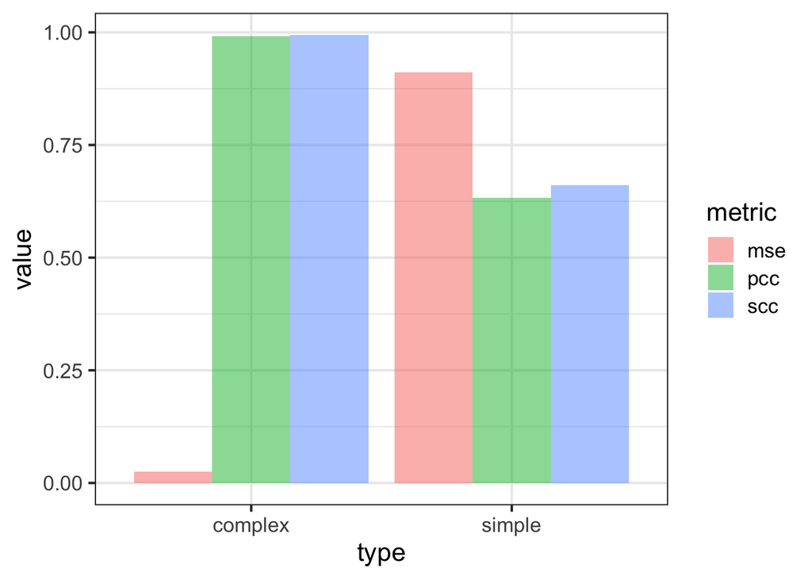

*metrics:*

- mse = mean-squared-error (low is good)
- pcc = pearson’s correlation coefficient (high is good)
- scc = spearman’s correlation coefficient (high is good)

It looks pretty good. A good job has been done, start with a simple baseline model and see if you can capture more of the signal with a more sophisticated model. Given your experience you of course want to see the more than a few metrics summarising the model performances, so you plot the classic machine learning measured-versus-predicted machine learning plot:

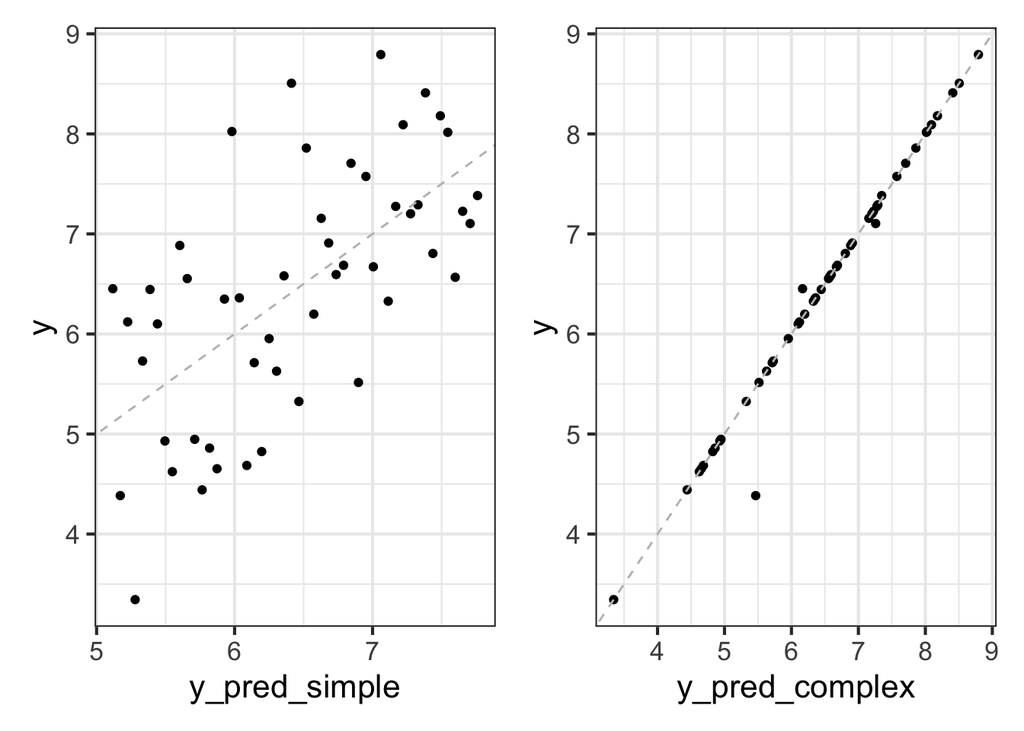

*The dashed line is the identity, i.e. when the observed values are equal to those predicted by the model.*

Ok, evidently, the more complex model captures the signal very nicely, whereas the more simple seem to going in the right direction, but not really capturing the subtle differences making up this data.

Now, go to R/06_a_case_story.R (This script is also in the directory `/R` of your RStudio session) and let us try to work a bit more on this. *NB! Try to not look at the model objects, as this will give away the point of this particular exercise*

- **Q1**: Discuss with your breakout room buddy: What in the world is going on? Same data source, same models!?
- **Q2**: Discuss with your breakout room buddy: What in the world is going on? In the “Case data new models” the performance is going down with higher values of alpha and in the “New data new models”, performance is going up with higher values of alpha!?
- **Q3**: Again, discuss with your break-out room partner: Interpret and explain what is going on here?
- **Q4**: Again, discuss with your break-out room partner: Interpret and explain what is going on here?

**When you are done thinking, click here for answers**

The essence here is the problem of overfitting. If you peak at the `R/89_utils_case_story.R`-file you can see, that the `data_generator()`-function, simply returns `3*x + 2 + rnorm(n, 3)`, i.e. a linear function with some noise added. The first models we play around with, you can also find in said file and the simple (and right) model is a linear regression (`lm()`), whereas the complex (and wrong) model is a local polynomial regression `loess`, with a low `span`-parameter (0.1) meaning a high emphasis on local fit, the result of which is a model capturing the added noise, rather than the general trend. This `span`-parameter is the one you end up tuning. In fact what you end up doing is identifying, that the best value for this parameters is something roughly above 1. If you read the helps for loess `?loess`, you will see that for `For a > 1, all points are used`, meaning that you are not far off from `lm`. This is also what you see in the final two plots. The tuned complex `loess`-model is roughly overlapping your simple `lm`-model.

Take home message: BE SUPER AWARE OF OVERFITTING! It is potentially detrimental to the application of your model, which can end up being very expensive. Furthermore, in this case, it would have relatively easy to capture early on, but here we only worked with 2 parameters, whereas if you did the exercise with the peptides, we were working on roughly a quarter of a million parameters. In very high dimensional parameters space, overfitting may be a lot less obvious.